## **01. Data analysis - basics**

### **Exercise 01**

Using the cars data set draw a scatter plot where the first variable is speed and the second is breaking distance.

Fit a regression line and plot it on the graph.

Try to match the square and cubic function. Add them to the chart.

Suggest a model based on its quality.

##### **1.1 Load libraries, check data set, assign to variable**

50 data points, 2 numeric columns: speed (mph) and stopping distance (ft).

```r
# Libraries
library(ggplot2)
library(wesanderson)

# Color palette
moon <- wes_palette('Moonrise2', n=4, type = 'discrete')

# Summary statistic of data set
skimr::skim(cars)
```

Data summary

| Name | cars |
| --- | --- |
| Number of rows | 50 |
| Number of columns | 2 |
| _______________________ |  |
| Column type frequency: |  |
| numeric | 2 |
| ________________________ |  |
| Group variables | None |

**Variable type: numeric**

| skim_variable | n_missing | complete_rate | mean | sd | p0 | p25 | p50 | p75 | p100 | hist |
| --- | --- | --- | --- | --- | --- | --- | --- | --- | --- | --- |
| speed | 0 | 1 | 15.40 | 5.29 | 4 | 12 | 15 | 19 | 25 | ▂▅▇▇▃ |
| dist | 0 | 1 | 42.98 | 25.77 | 2 | 26 | 36 | 56 | 120 | ▅▇▅▂▁ |

```r
# Assign data set to variable
dataset01 <- cars
```

##### **1.2 Scatter plot with line models**

3 models combined on one graph:

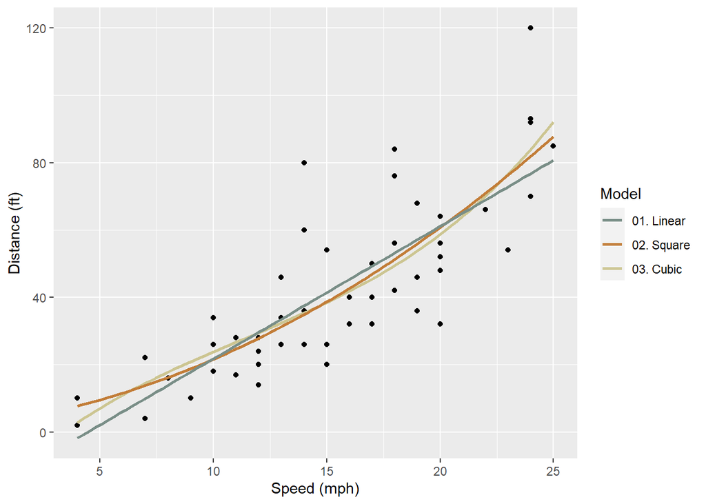

```r
ggplot(data = dataset01, aes(x = speed, y = dist)) +
  geom_point() +
  # Cubic model
  geom_smooth(method = 'lm', se = FALSE, formula = y ~ poly(x, 3), aes(colour = '03. Cubic')) +
  # Square model
  geom_smooth(method = 'lm', se = FALSE, formula = y ~ poly(x, 2), aes(colour = '02. Square')) +
  # Linear model
  geom_smooth(method = 'lm', se = FALSE, aes(colour = '01. Linear')) +
  # Lines color
  scale_color_manual(name = 'Model', values = wes_palette('Moonrise2', type = "discrete", n = 4)) +
  # Axis labels
  labs(x = 'Speed (mph)', y = 'Distance (ft)')
```

Separate graphs:

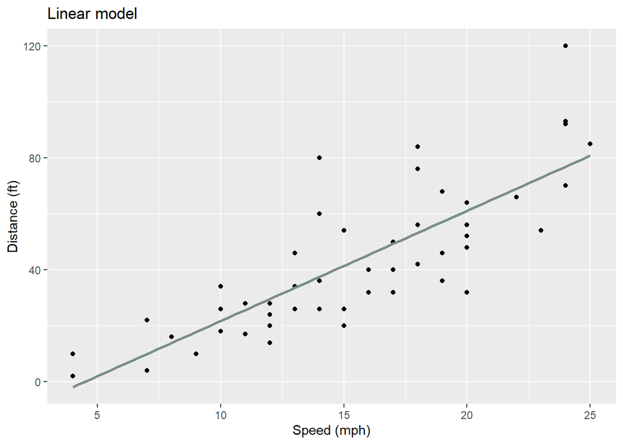

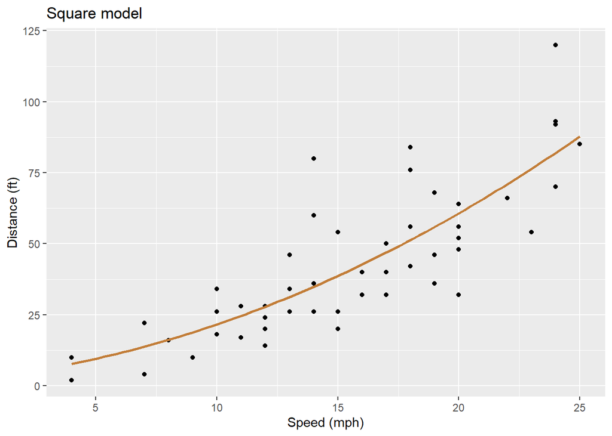

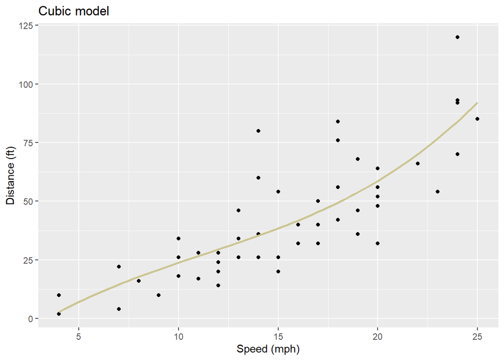

##### **1.3 Linear models**

```r
# Linear model (Model 1A)
model_1a = lm(formula = dist ~ speed, data = dataset01)

# Square model (Model 1B)
model_1b = lm(dist ~ poly(speed, 2, raw = TRUE), data = dataset01)

# Cubic model (Model 1C)
model_1c = lm(dist ~ poly(speed, 3, raw = TRUE), data = dataset01)
```

##### **1.4 Models summary and comparison**

**Multiple R-squared** - best result for model 1C: model 1C explains variance in stopping distance in 67%. The more complex model, the better it fits into data points (1A = 0.6510794, 1B = 0.6673308, 1C = 0.6731808).

**p-value** - best result for model 1A (1A = 1.4898365^{-12}, 1B = 5.8518805^{-12}, 1C = 3.0744448^{-11}, but it’s ok for all models, less than 0.05).

```r
summary(model_1a)
```

```
##
## Call:
## lm(formula = dist ~ speed, data = dataset01)
##
## Residuals:
##     Min      1Q  Median      3Q     Max
## -29.069  -9.525  -2.272   9.215  43.201
##
## Coefficients:
##             Estimate Std. Error t value Pr(>|t|)
## (Intercept) -17.5791     6.7584  -2.601   0.0123 *
## speed         3.9324     0.4155   9.464 1.49e-12 ***
## ---
## Signif. codes:  0 '***' 0.001 '**' 0.01 '*' 0.05 '.' 0.1 ' ' 1
##
## Residual standard error: 15.38 on 48 degrees of freedom
## Multiple R-squared:  0.6511, Adjusted R-squared:  0.6438
## F-statistic: 89.57 on 1 and 48 DF,  p-value: 1.49e-12
```

```r
summary(model_1b)
```

```
##
## Call:
## lm(formula = dist ~ poly(speed, 2, raw = TRUE), data = dataset01)
##
## Residuals:
##     Min      1Q  Median      3Q     Max
## -28.720  -9.184  -3.188   4.628  45.152
##
## Coefficients:
##                             Estimate Std. Error t value Pr(>|t|)
## (Intercept)                  2.47014   14.81716   0.167    0.868
## poly(speed, 2, raw = TRUE)1  0.91329    2.03422   0.449    0.656
## poly(speed, 2, raw = TRUE)2  0.09996    0.06597   1.515    0.136
##
## Residual standard error: 15.18 on 47 degrees of freedom
## Multiple R-squared:  0.6673, Adjusted R-squared:  0.6532
## F-statistic: 47.14 on 2 and 47 DF,  p-value: 5.852e-12
```

```r
summary(model_1c)
```

```
##
## Call:
## lm(formula = dist ~ poly(speed, 3, raw = TRUE), data = dataset01)
##
## Residuals:
##     Min      1Q  Median      3Q     Max
## -26.670  -9.601  -2.231   7.075  44.691
##
## Coefficients:
##                              Estimate Std. Error t value Pr(>|t|)
## (Intercept)                 -19.50505   28.40530  -0.687    0.496
## poly(speed, 3, raw = TRUE)1   6.80111    6.80113   1.000    0.323
## poly(speed, 3, raw = TRUE)2  -0.34966    0.49988  -0.699    0.488
## poly(speed, 3, raw = TRUE)3   0.01025    0.01130   0.907    0.369
##
## Residual standard error: 15.2 on 46 degrees of freedom
## Multiple R-squared:  0.6732, Adjusted R-squared:  0.6519
## F-statistic: 31.58 on 3 and 46 DF,  p-value: 3.074e-11
```

**MSE (Mean Squared Error)** - best result for 1C.

```r
mean(resid(model_1a)^2)
```

```
## [1] 227.0704
```

```r
mean(resid(model_1b)^2)
```

```
## [1] 216.4943
```

```r
mean(resid(model_1c)^2)
```

```
## [1] 212.6872
```

```r
# Akaike
AIC(model_1a, model_1b, model_1c)
```

```
##          df      AIC
## model_1a  3 419.1569
## model_1b  4 418.7721
## model_1c  5 419.8850
```

```r
# Bayesian
BIC(model_1a, model_1b, model_1c)
```

```
##          df      BIC
## model_1a  3 424.8929
## model_1b  4 426.4202
## model_1c  5 429.4451
```

For prediction the best is **model 1A**, as it’s the simplest one, shows pattern in data and have good parameters comparing to square & cubic models.

### **Exercise 02**

Make a correlation diagram and find a regression line for the house price and number of rooms data.

With significance level = 5%, does the number of rooms have an impact on the price?

What will be the price of the two-room apartment according to the estimated model?

Are the assumptions of the model fulfilled?

##### **2.1 Create data set**

```r
# Data set
price <- c(300, 250, 400, 550, 317, 389, 425, 289, 389, 559)
rooms <- c(3, 3, 4, 5, 4, 3, 6, 3, 4, 5)

dataset02 <- data.frame(price,rooms)
```

##### **2.2 Scatter plot**

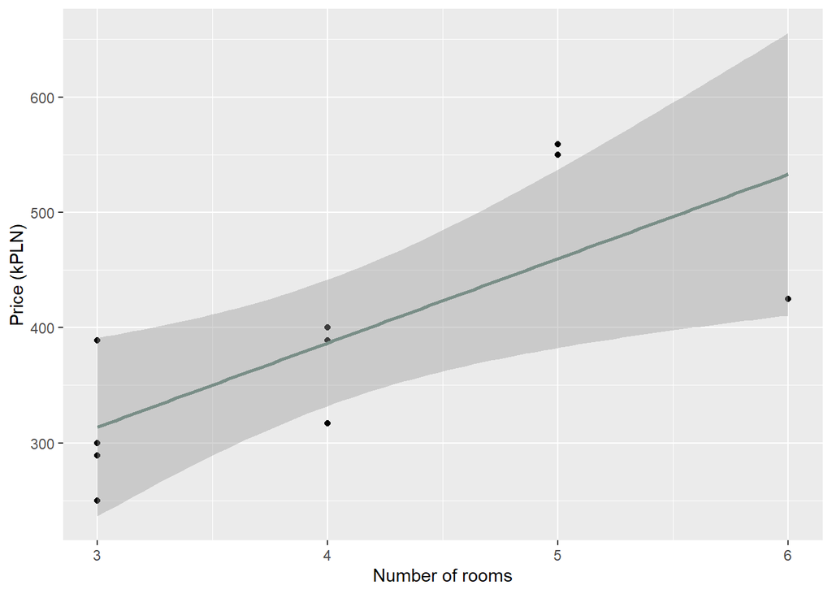

```r
ggplot(data = dataset02, aes(x = rooms, y = price)) +
  geom_point() +
  geom_smooth(method = 'lm', color = moon[1]) +
  labs(x = 'Number of rooms', y = 'Price (kPLN)')
```

##### **2.3 Model summary**

**Residuals**: we aim at symmetrical residuals. Not bad, but there might be some outliers. More detailed analysis can be done with residuals histogram, normal Q-Q, residuals vs fitted and residuals vs leverage plots.

**Adjusted R-squared = 0.4846** (variance in price of the apartment depends on 48% on the number of rooms). Not good enough, we aim for at least 0.6.

**p-value**: 0.01521 (OK, less than significance level = 0.05)

**Coefficient estimates**:

- **Intercept**: defines a point of crossing y axis. In theory, 0-rooms apartment would cost 94.4k PLN.
- **Rooms**: defines the slope. In our case: with each extra room price will increase by 73.1k PLN.

**Residual standard error**: on average, actual price deviates by 75.15k PLN from linear model.

```r
model_2a = lm(price ~ rooms, data = dataset02)
summary(model_2a)
```

```
##
## Call:
## lm(formula = price ~ rooms, data = dataset02)
##
## Residuals:
##     Min      1Q  Median      3Q     Max
## -108.00  -53.95   -5.75   59.77   99.10
##
## Coefficients:
##             Estimate Std. Error t value Pr(>|t|)
## (Intercept)    94.40      97.98   0.963   0.3635
## rooms          73.10      23.76   3.076   0.0152 *
## ---
## Signif. codes:  0 '***' 0.001 '**' 0.01 '*' 0.05 '.' 0.1 ' ' 1
##
## Residual standard error: 75.15 on 8 degrees of freedom
## Multiple R-squared:  0.5419, Adjusted R-squared:  0.4846
## F-statistic: 9.462 on 1 and 8 DF,  p-value: 0.01521
```

**cor = 0.7361** (strong positive correlation)

```r
cor.test(~ price + rooms, data = dataset02)
```

```
##
##  Pearson's product-moment correlation
##
## data:  price and rooms
## t = 3.076, df = 8, p-value = 0.01521
## alternative hypothesis: true correlation is not equal to 0
## 95 percent confidence interval:
##  0.1984755 0.9332160
## sample estimates:
##       cor
## 0.7361131
```

**Residuals histogram**: histogram suggests that the residuals are not normally distributed (left skewed) and there are some outliers.

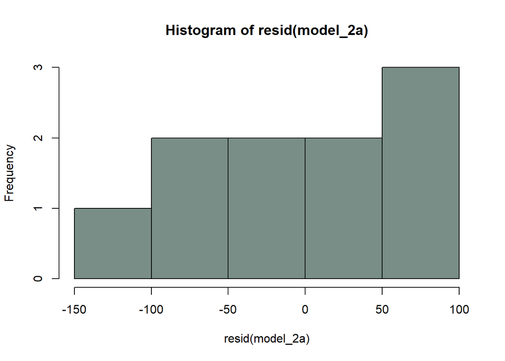

```r
hist(resid(model_2a), col = moon[1])
```

##### **2.4 Predict price of 2-rooms apartment**

Linear regression function: $y = a * x + b$, where y = price, x = number of rooms, a = coeff. rooms (from model_2a summary), b = coeff. estimate (from model_2a summary).

```r
# Create data set with known variable
tworooms <- data.frame(rooms=c(2))

# Use predict function using linear model
predict(model_2a,tworooms)
```

```
##     1
## 240.6
```

**ANSWER**: With significance level = 0.05 assumptions of model are met. There is strong positive correlation between number of rooms and the price (price depends on 73% on number of the rooms). Possibly, with removing outlier observation, general parameters of the model (adjusted R-squared, p-value, normality etc.) can improve.

Predicted price of 2 rooms apartment: 240.6 k PLN.

##### **2.5 Additional analysis for outlier**

Let’s check, which observation is outlier - based on scatter plot it might be apartment with 6 rooms (obs. #7), which is far from other points.

**Residuals vs. fitted plot**: points are not symmetrically distributed, there are potential outliers (observation #7, #10 and #4)

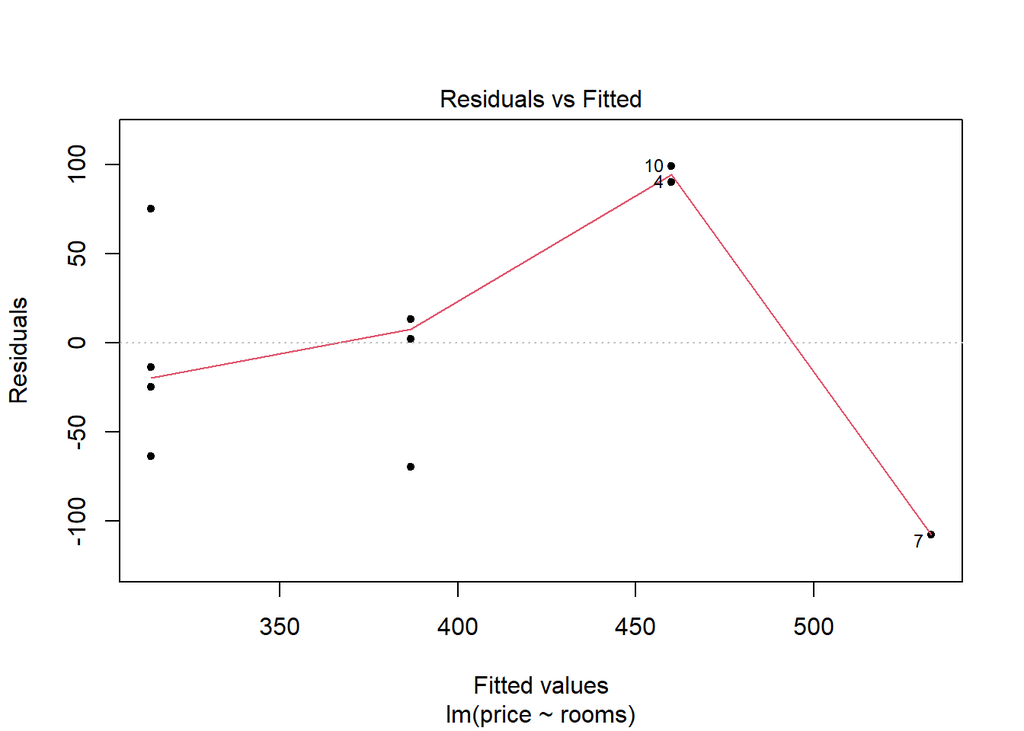

```r
# Residuals vs fitted plot
plot(model_2a, 1, pch = 20)
```

**Normal probability plot (Q-Q)** : observations #10 and #7 are potential outliers.

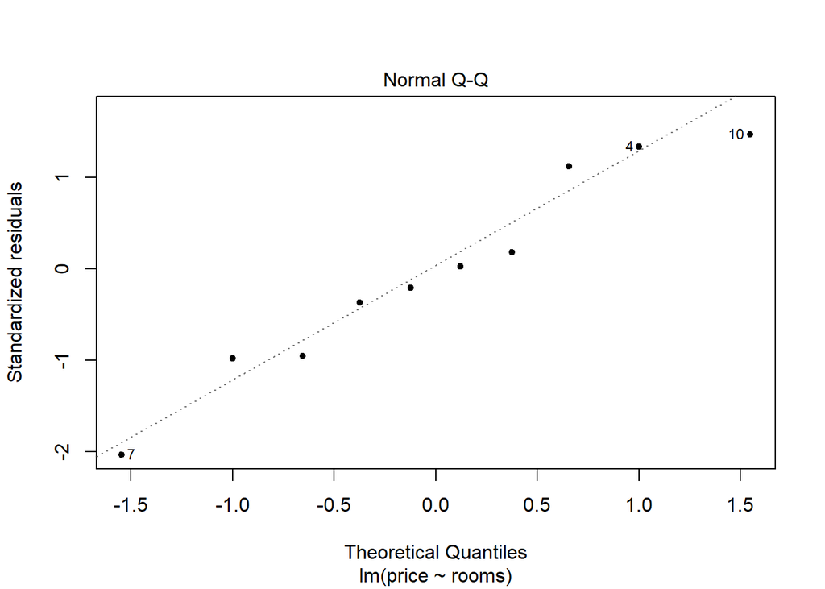

```r
plot(model_2a, 2, pch = 20)
```

**Residuals vs. leverage plot**: obs. #7 highly influences the regression line.

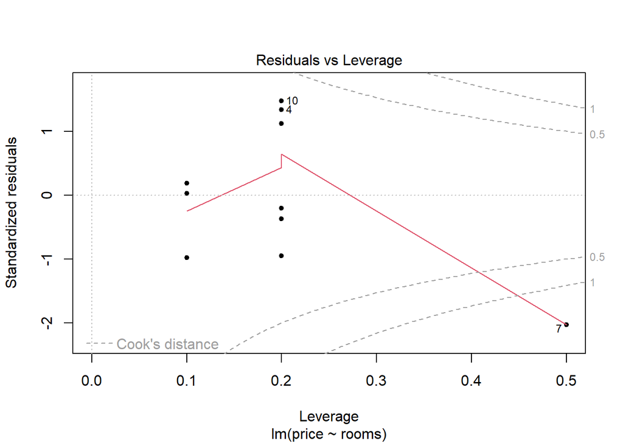

```r
plot(model_2a, 5, pch = 20)
```

***

Based on above analysis, we will remove observation #7 from data set and check parameters of new model:

1. Divide data set: observations w/o outlier + outlier (#7),
2. Create new model w/o outlier,
3. Create scatter plot to compare linear models (with all observations and w/o outlier) and influential observation,
4. Compare parameters of those models.

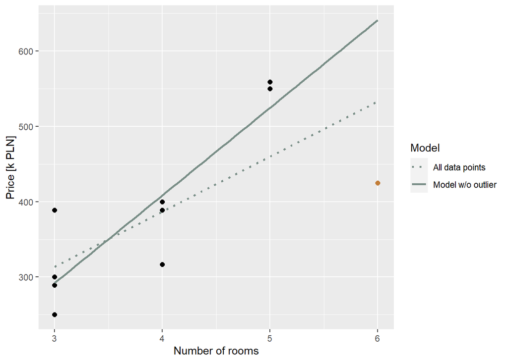

```r
dataset02A <- dataset02[-7,]  # data set w/o outlier
dataset02B <- dataset02[7,]   # outlier

ggplot(data = dataset02, aes(x = rooms, y = price))+
  # Data points w/o outlier
  geom_point(data = dataset02A, aes(x = rooms, y = price), size = 2, colour = 1) +
  # Outlier
  geom_point(data=dataset02B, aes(x = rooms, y = price), size = 2, colour = moon[2]) +
  # Linear model w/o outlier
  geom_smooth(data = dataset02A, method = 'lm', fullrange = TRUE, se = FALSE,
              aes(x = rooms, y = price,
                  colour = 'Model w/o outlier', linetype = 'Model w/o outlier')) +
  # Linear model with all observations
  geom_smooth(data = dataset02, method = 'lm', fullrange = TRUE, se = FALSE,
              aes(x = rooms, y = price,
                  colour = 'All data points', linetype = 'All data points')) +
  # Color & line types
  scale_color_manual(name = 'Model', values = c(moon[1],moon[1]))+
  scale_linetype_manual(name = 'Model', values = c(3,1)) +
  # Axis labels
  labs(x = 'Number of rooms', y = 'Price [k PLN]')
```

**New model summary:**

**Residuals**: more symmetrical distribution, from -91.4 to 96.9 (vs -108.00 to 99.10 in 2A, improvement)

**Adjusted R-squared**: 0.7425 (vs 0.4846 in 2A, improvement)

**p-value**: 0.001741 (vs 0.01521 in 2A, improvement)

```r
model_2b = lm(price ~ rooms, data = dataset02A)
summary(model_2b)
```

```
##
## Call:
## lm(formula = price ~ rooms, data = dataset02A)
##
## Residuals:
##    Min     1Q Median     3Q    Max
##  -91.4  -19.4   -3.1   25.3   96.9
##
## Coefficients:
##             Estimate Std. Error t value Pr(>|t|)
## (Intercept)   -56.80      91.47  -0.621  0.55428
## rooms         116.30      23.70   4.906  0.00174 **
## ---
## Signif. codes:  0 '***' 0.001 '**' 0.01 '*' 0.05 '.' 0.1 ' ' 1
##
## Residual standard error: 55.87 on 7 degrees of freedom
## Multiple R-squared:  0.7747, Adjusted R-squared:  0.7425
## F-statistic: 24.07 on 1 and 7 DF,  p-value: 0.001741
```

**Significance of Pearson’s coeff.**: cor = 0.88 (vs 0.7361 in 2A)

```r
cor.test(~ price + rooms, data = dataset02A)
```

```
##
##  Pearson's product-moment correlation
##
## data:  price and rooms
## t = 4.9063, df = 7, p-value = 0.001741
## alternative hypothesis: true correlation is not equal to 0
## 95 percent confidence interval:
##  0.5200479 0.9746012
## sample estimates:
##      cor
## 0.880178
```

**Residuals histogram**: residuals are now normally distributed.

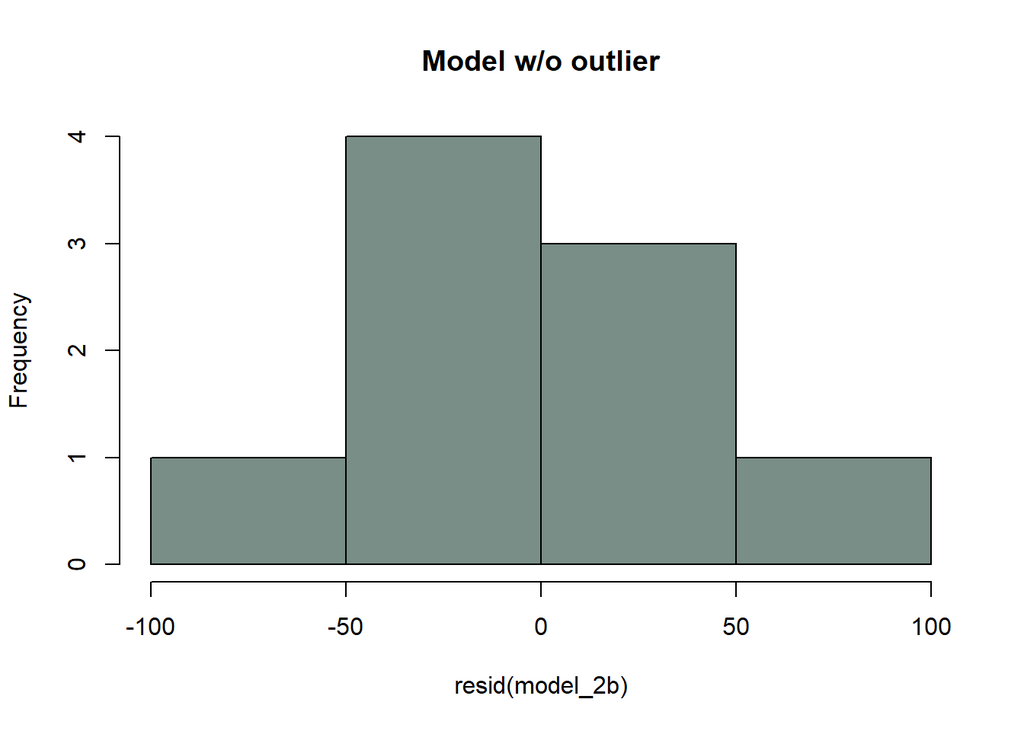

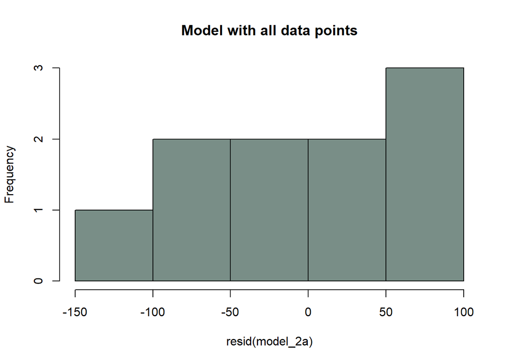

```r
hist(resid(model_2b), col = moon[1], main = 'Model w/o outlier')
hist(resid(model_2a), col = moon[1], main = 'Model with all data points')
```

**Residuals vs fitted**: points are more symmetrically distributed, red line is more straight. New potential outliers: #5 and #6.

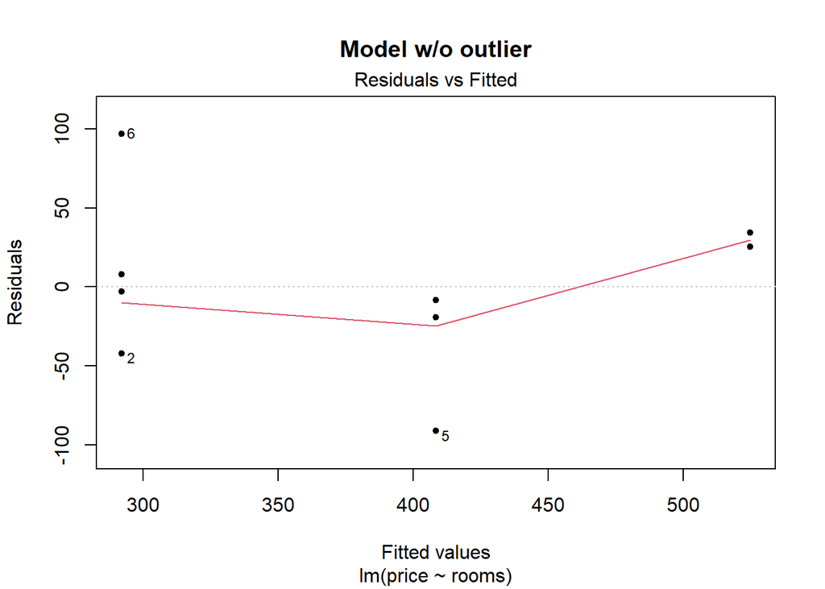

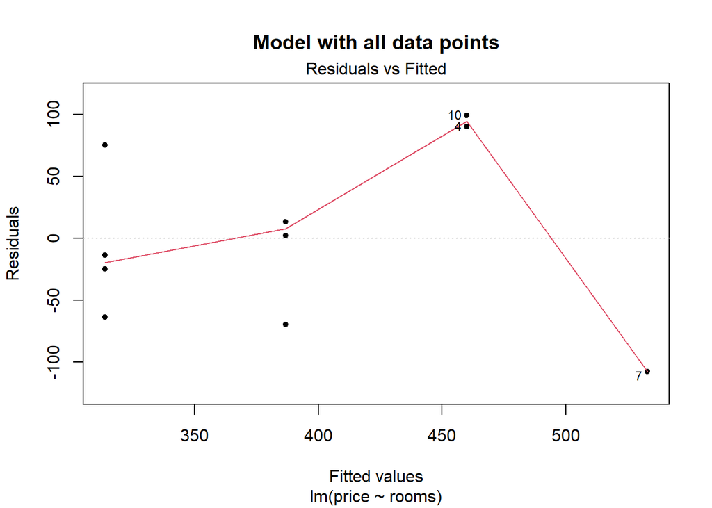

```r
plot(model_2b, 1, pch = 20, main = 'Model w/o outlier')
plot(model_2a, 1, pch = 20, main = 'Model with all data points')
```

**Normality**: OK in our case - rather symmetrical, potential outliers: #5, #6. Similar shape to model with all data points.

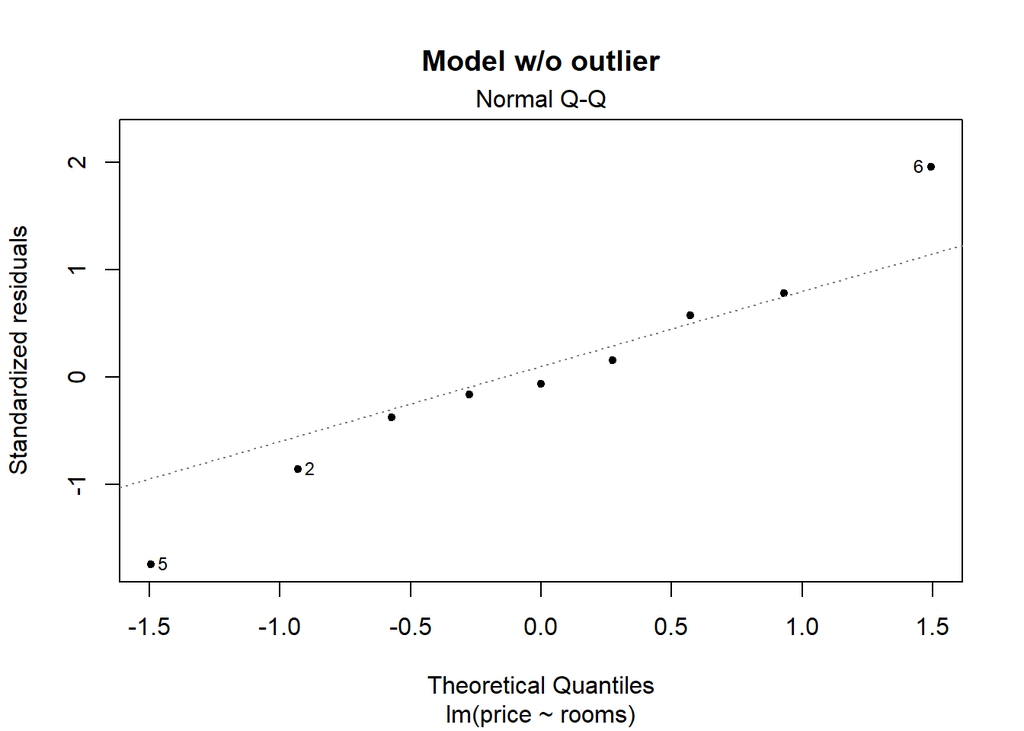

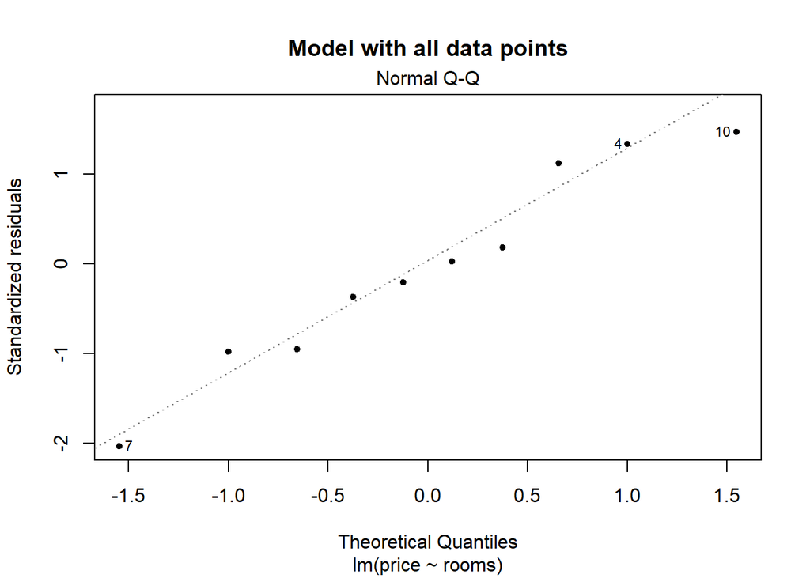

```r
plot(model_2b, 2, pch = 20, main = 'Model w/o outlier')
plot(model_2a, 2, pch = 20, main = 'Model with all data points')
```

**Influential points**: points are closer to the center, graph looks much better than in previous model. Observation #6 might be another potential outlier.

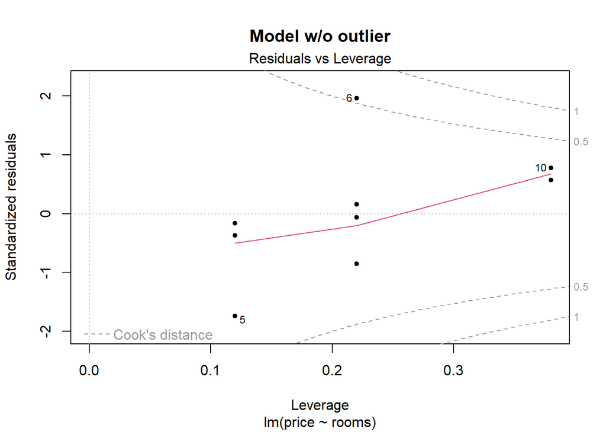

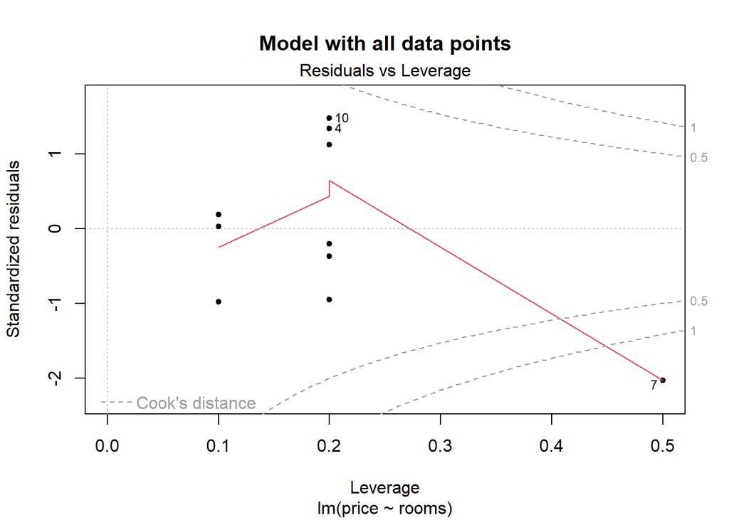

```r
plot(model_2b, 5, pch = 20, main = 'Model w/o outlier')
plot(model_2a, 5, pch = 20, main = 'Model with all data points')
```

### **Exercise 03**

In the emissions data set from the package UsingR (CO2 emissions vs. GDP level, 26 countries) there is at least one outlier.

Draw a correlation diagram for variables GDP and CO2. Based on it, determine the outlier.

Accepting variable CO2 behind the dependent variable, find the regression line with an outlier and without it.

How have the results changed? Add both lines to the graph.

##### **3.1 Load libraries, check data set, assign to variable**

No missing values, 26 data points, 3 numeric variables (GDP, GDP per Capita and CO2 emission)

```r
# Library
library(UsingR)

# Summary statistic
skimr::skim(emissions)
```

Data summary

| Name | emissions |
| --- | --- |
| Number of rows | 26 |
| Number of columns | 3 |
| _______________________ |  |
| Column type frequency: |  |
| numeric | 3 |
| ________________________ |  |
| Group variables | None |

**Variable type: numeric**

| skim_variable | n_missing | complete_rate | mean | sd | p0 | p25 | p50 | p75 | p100 | hist |
| --- | --- | --- | --- | --- | --- | --- | --- | --- | --- | --- |
| GDP | 0 | 1 | 830426.92 | 1633360.09 | 59900 | 123100.00 | 206250 | 683500.00 | 8083000 | ▇▁▁▁▁ |
| perCapita | 0 | 1 | 17724.46 | 7350.48 | 2507 | 13393.25 | 20993 | 22249.75 | 29647 | ▃▁▂▇▂ |
| CO2 | 0 | 1 | 669.38 | 1343.35 | 54 | 77.00 | 200 | 547.50 | 6750 | ▇▁▁▁▁ |

```r
# Assign data set to variable
dataset03 <- emissions
```

##### **3.2 Scatter plot with linear model**

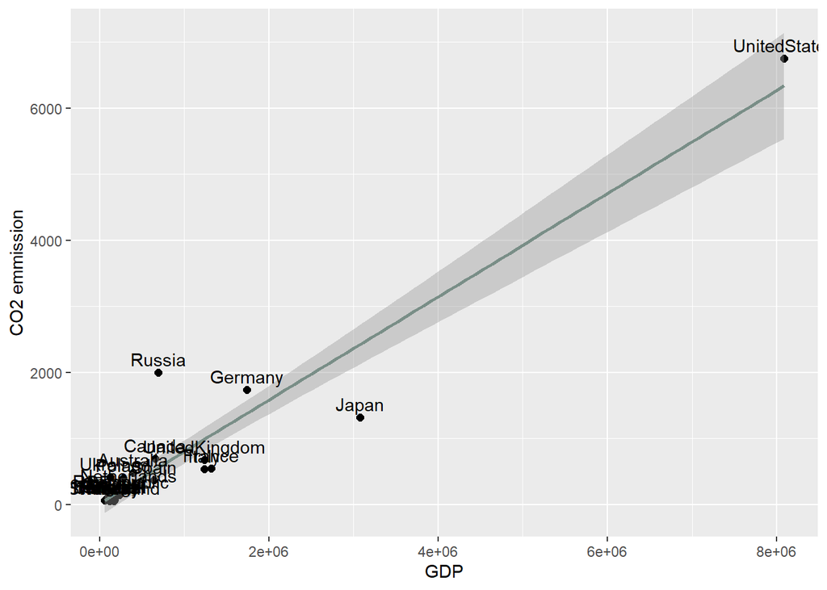

```r
ggplot(data = dataset03, aes(x = GDP, y = CO2)) +
  geom_point(size = 2) +
  geom_smooth(method = 'lm', color = moon[1]) +
  geom_text(label = rownames(dataset03), hjust = 0.5, vjust = -0.5) +
  labs(x = 'GDP', y = 'CO2 emmission')
```

**Outliers based on scatter plot:** USA, Russia and Japan. Although USA falls within 95% confidence interval, its GDP and CO2 emission are much higher than median values for whole data set (observation point is far from other points, clustered close to the beginning of coordinates system).  
**Outlier chosen: USA.**

```r
# USA values
dataset03['UnitedStates',]
```

```
##                  GDP perCapita  CO2
## UnitedStates 8083000     29647 6750
```

```r
# Median for data set
library(magrittr)
skimr::skim(emissions) %>% dplyr::select(numeric.p50)
```

```
## # A tibble: 3 × 1
##   numeric.p50
##         <dbl>
## 1      206250
## 2       20993
## 3         200
```

##### **3.3 Model summary**

**Adjusted R-squared:** 0.8988

**p-value:** 1.197e-13 (below significance level = 0.05)

```r
model_3a <- lm(CO2 ~ GDP, data = dataset03)
summary(model_3a)
```

```
##
## Call:
## lm(formula = CO2 ~ GDP, data = dataset03)
##
## Residuals:
##      Min       1Q   Median       3Q      Max
## -1107.35   -81.47   -32.69   126.33  1438.79
##
## Coefficients:
##              Estimate Std. Error t value Pr(>|t|)
## (Intercept) 2.043e+01  9.441e+01   0.216     0.83
## GDP         7.815e-04  5.233e-05  14.933  1.2e-13 ***
## ---
## Signif. codes:  0 '***' 0.001 '**' 0.01 '*' 0.05 '.' 0.1 ' ' 1
##
## Residual standard error: 427.4 on 24 degrees of freedom
## Multiple R-squared:  0.9028, Adjusted R-squared:  0.8988
## F-statistic:   223 on 1 and 24 DF,  p-value: 1.197e-13
```

##### **3.4 Removing outlier (USA), creating new model**

```r
countries_remove <- c('UnitedStates')

# w/o USA
dataset03_A <- dataset03[!(rownames(dataset03) %in% countries_remove),]

# USA only
dataset03_USA <- dataset03[(rownames(dataset03) %in% countries_remove),]
```

Scatter plot:

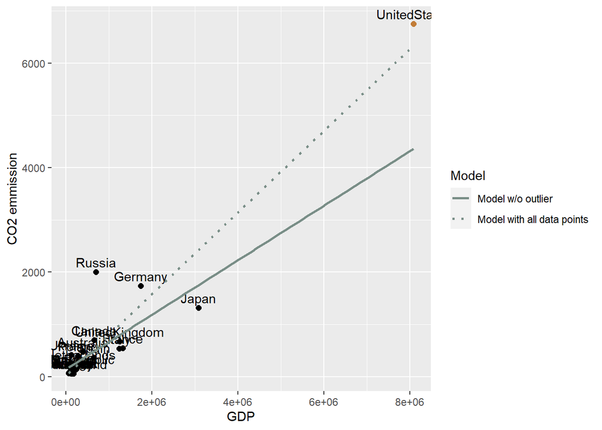

```r
(g <- ggplot(data = dataset03, aes(x = GDP, y=CO2)) +
  # Data points
  geom_point(data = dataset03_A, color = 1, size = 2, aes(x = GDP, y=CO2)) +
  # Outlier
  geom_point(data = dataset03_USA, color = moon[2], size = 2, aes(x = GDP, y=CO2)) +
  # Point labels
  geom_text(label = rownames(dataset03), hjust = 0.5, vjust = -0.5) +
  # Linear model w/o outlier
  geom_smooth(data = dataset03_A, method = 'lm', fullrange = TRUE, se = FALSE,
              aes(x = GDP, y = CO2,
                  color ='Model w/o outlier', linetype = 'Model w/o outlier')) +
  # Linear model with all data points
  geom_smooth(data = dataset03, method = 'lm', fullrange = TRUE, se = FALSE,
              aes(x = GDP, y = CO2,
                  color = 'Model with all data points', linetype = 'Model with all data points')) +
  # Lines color & type
  scale_color_manual(name = 'Model', values = c(moon[1],moon[1])) +
  scale_linetype_manual(name = 'Model', values = c(1,3)) +
  # Axis labels
  labs(x = 'GDP', y = 'CO2 emmission'))
```

Zoom in to countries clustered at the beginning of coordinates system:

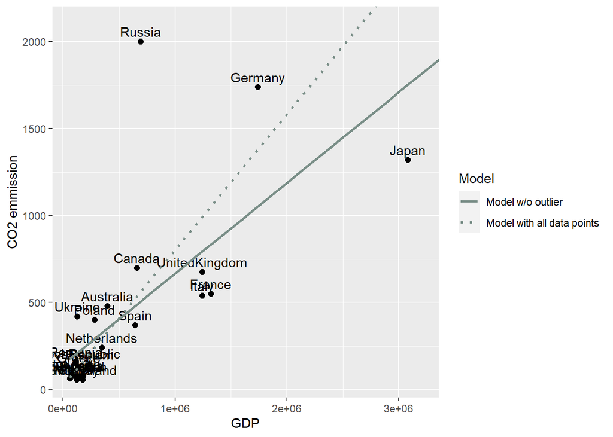

```r
# Set limits on axis w/o removing data points outside the range (USA)
g + coord_cartesian(xlim = c(NA,3200000), ylim = c(NA,2100))
```

##### **3.5 Summary of new model (w/o USA)**

**Adjusted R-squared:** 0.4679 (vs 0.8988 in model_3a)

**p-value:** 9.802e-05 (vs 1.197e-13 in model_3a)

```r
model_3b <- lm(data = dataset03_A, CO2 ~ GDP)
summary(model_3b)
```

```
##
## Call:
## lm(formula = CO2 ~ GDP, data = dataset03_A)
##
## Residuals:
##     Min      1Q  Median      3Q     Max
## -431.20 -151.12 -112.51  -43.84 1494.71
##
## Coefficients:
##              Estimate Std. Error t value Pr(>|t|)
## (Intercept) 1.443e+02  9.749e+01   1.480    0.153
## GDP         5.217e-04  1.110e-04   4.701  9.8e-05 ***
## ---
## Signif. codes:  0 '***' 0.001 '**' 0.01 '*' 0.05 '.' 0.1 ' ' 1
##
## Residual standard error: 384.3 on 23 degrees of freedom
## Multiple R-squared:   0.49,  Adjusted R-squared:  0.4679
## F-statistic:  22.1 on 1 and 23 DF,  p-value: 9.802e-05
```

**Residuals histogram**: not symmetrical, right skewed

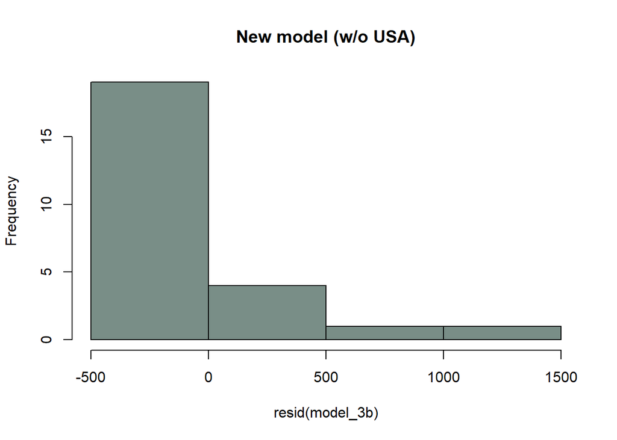

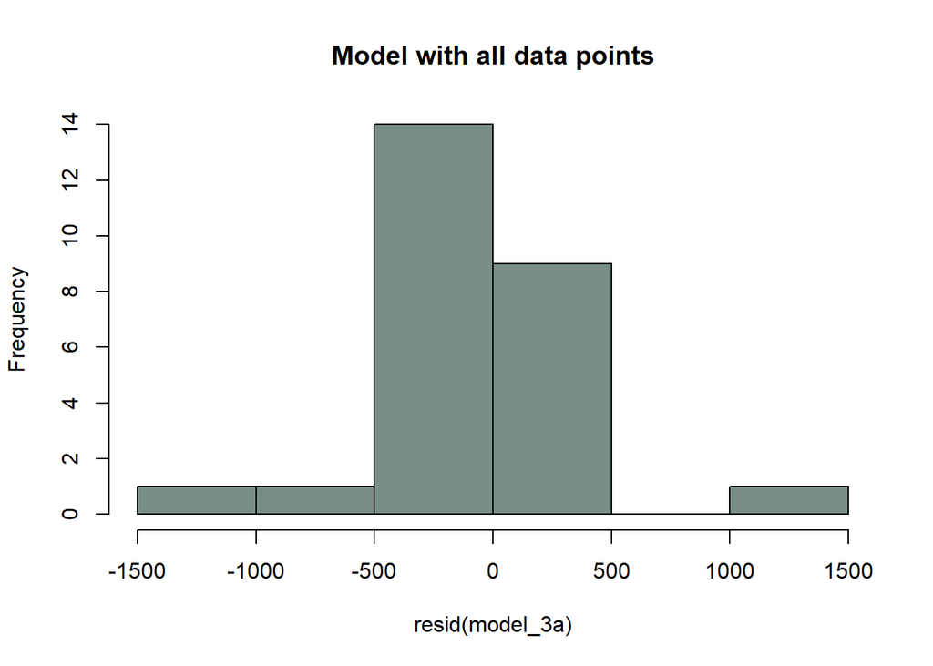

```r
hist(resid(model_3b), col = moon[1], main = 'New model (w/o USA)')
hist(resid(model_3a), col = moon[1], main = 'Model with all data points')
```

**Residuals vs fitted**: line is more parallel to the center, but there are still extreme values (Russia, Germany)

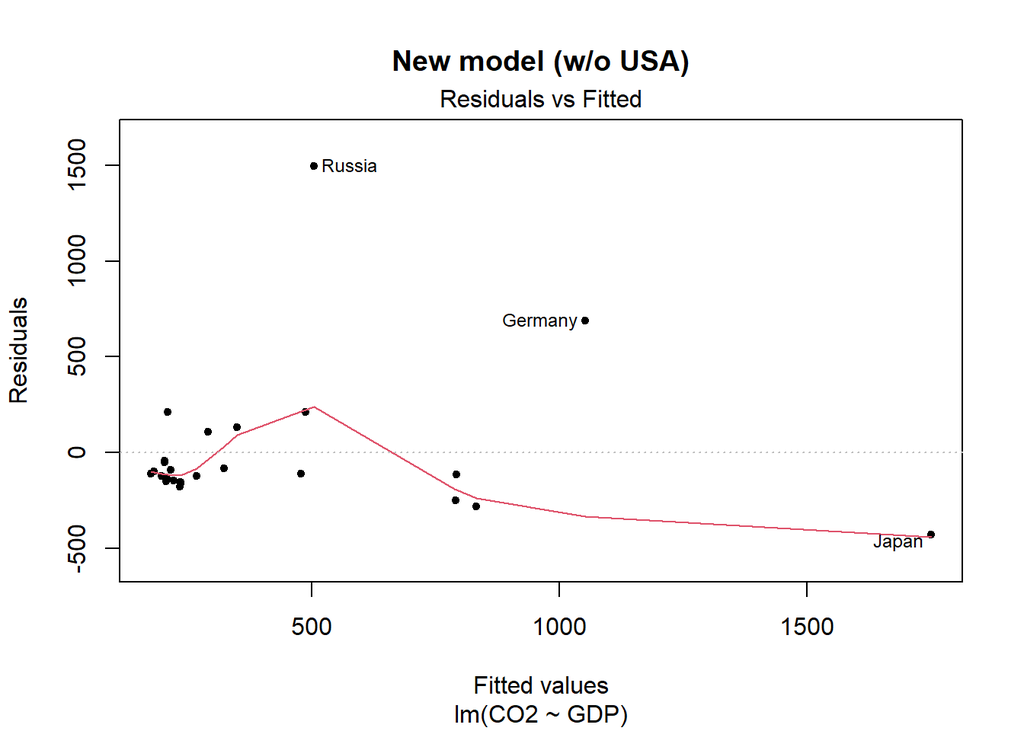

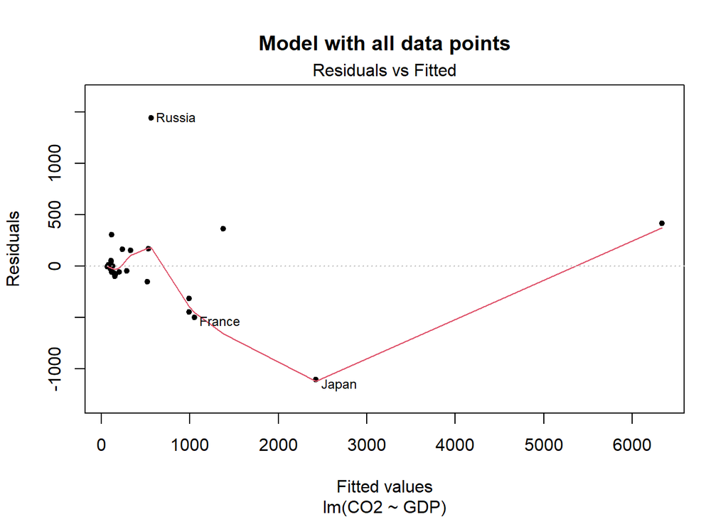

```r
plot(model_3b, 1, pch = 20, main = 'New model (w/o USA)')
plot(model_3a, 1, pch = 20, main = 'Model with all data points')
```

**Normality**: a little bit more symmetrical, higher impact from outliers: Russia, Germany

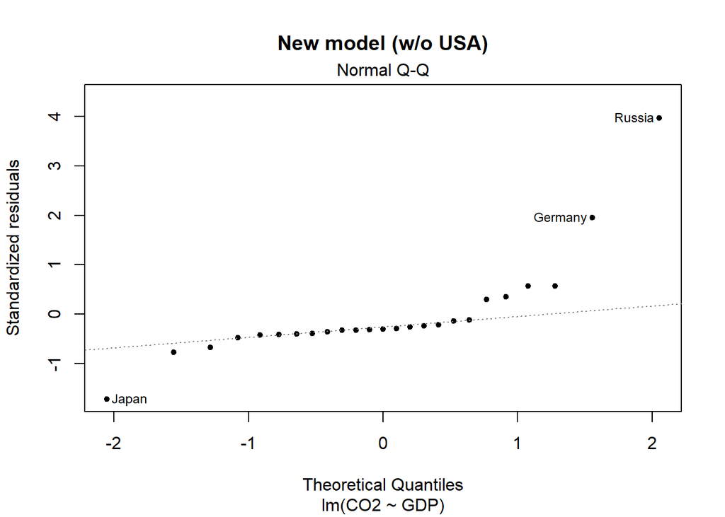

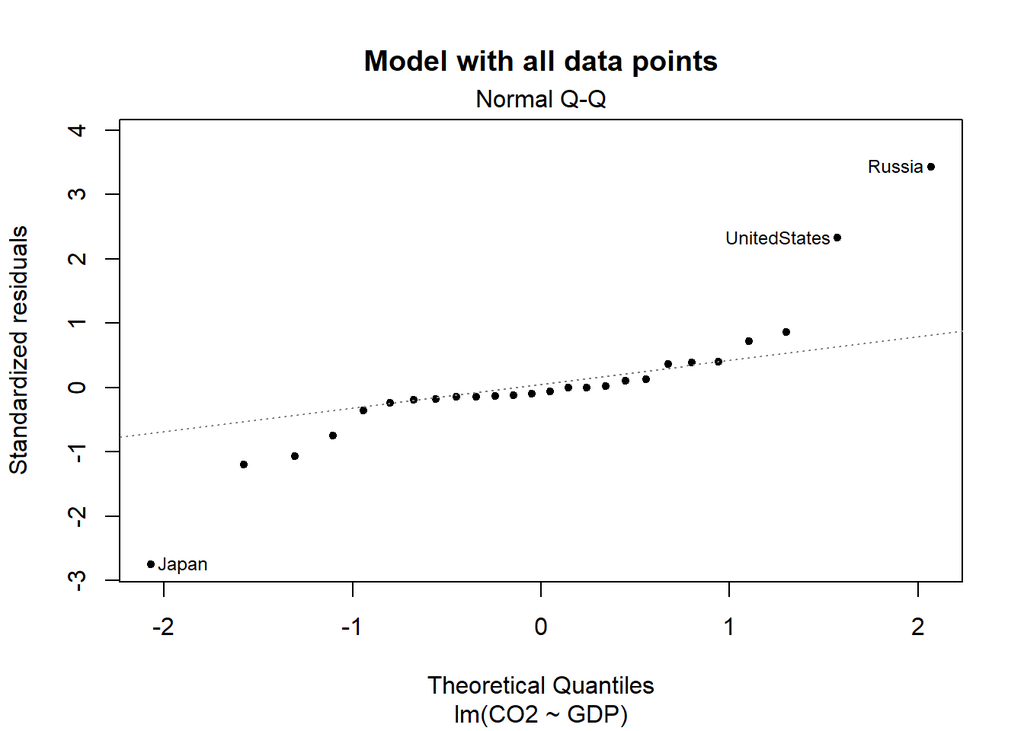

```r
plot(model_3b, 2, pch = 20, main = 'New model (w/o USA)')
plot(model_3a, 2, pch = 20, main = 'Model with all data points')
```

**Residuals vs leverage**: points closer to center, new influential points: Japan, Germany, Russia

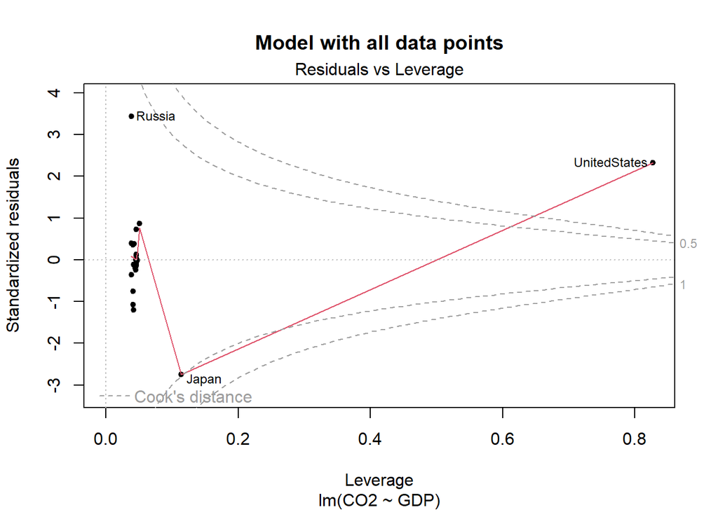

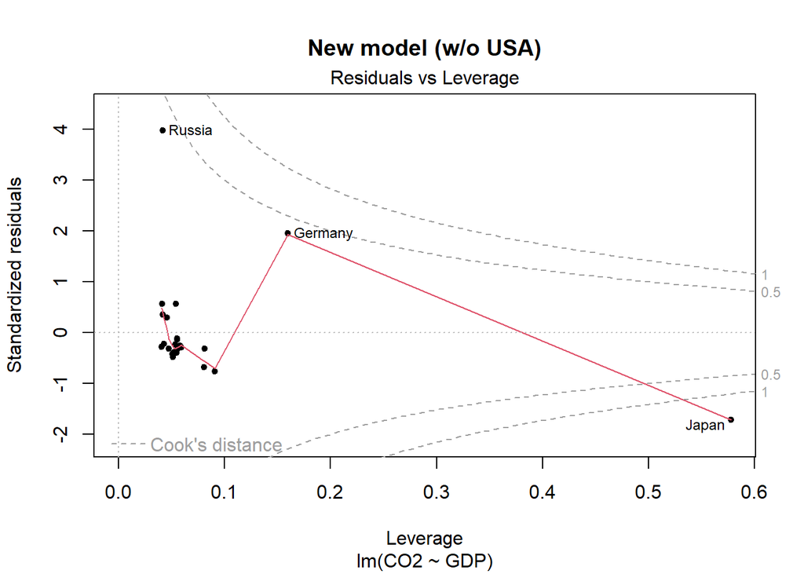

```r
plot(model_3a, 5, pch = 20, main = 'Model with all data points')
plot(model_3b, 5, pch = 20, main = 'New model (w/o USA)')
```

**SUMMARY**: With removing USA from the model, general parameters (R-squared and p-value) have worsen. Even though USA was far away from other points, it was relatively close to regression line. Now, impact from other outliers (Germany and Russia) is more visible.

### **Excercise 04**

The UsingR homeprice dataset contains information on homes sold in New Jersey in 2001.

Did the number of toilets (half) affect the price (sale)?

Are the assumptions of the model met?

##### **4.1 Check data set, assign to variable**

29 observations and 7 variables, no missing values.

```r
# Summary statistic
skimr::skim(homeprice)
```

Data summary

| Name | homeprice |
| --- | --- |
| Number of rows | 29 |
| Number of columns | 7 |
| _______________________ |  |
| Column type frequency: |  |
| numeric | 7 |
| ________________________ |  |
| Group variables | None |

**Variable type: numeric**

| skim_variable | n_missing | complete_rate | mean | sd | p0 | p25 | p50 | p75 | p100 | hist |
| --- | --- | --- | --- | --- | --- | --- | --- | --- | --- | --- |
| list | 0 | 1 | 274.85 | 120.43 | 43 | 189 | 275.0 | 339 | 599 | ▂▆▇▁▁ |
| sale | 0 | 1 | 273.52 | 117.34 | 48 | 185 | 272.5 | 340 | 613 | ▃▇▇▂▁ |
| full | 0 | 1 | 1.72 | 0.75 | 1 | 1 | 2.0 | 2 | 3 | ▇▁▇▁▃ |
| half | 0 | 1 | 0.66 | 0.67 | 0 | 0 | 1.0 | 1 | 2 | ▇▁▇▁▂ |
| bedrooms | 0 | 1 | 3.17 | 0.80 | 1 | 3 | 3.0 | 4 | 5 | ▁▂▇▃▁ |
| rooms | 0 | 1 | 7.21 | 1.52 | 3 | 7 | 7.0 | 8 | 11 | ▁▂▇▆▁ |
| neighborhood | 0 | 1 | 2.90 | 1.01 | 1 | 2 | 3.0 | 3 | 5 | ▁▅▇▃▁ |

```r
# Assign data set to variable
dataset04 <- homeprice
```

##### **4.2 Scatter plot**

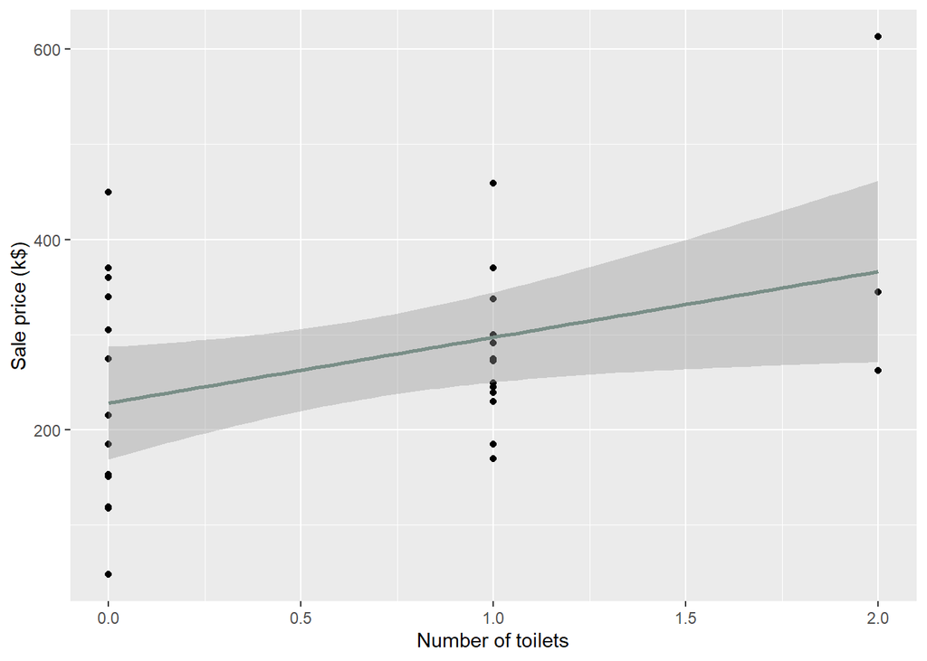

```r
ggplot(data = dataset04, aes(x = half, y = sale)) +
  geom_point() +
  geom_smooth(method = 'lm', color = moon[1]) +
  labs(x = 'Number of toilets', y = 'Sale price (k$)')
```